# Distinguishing some relationships of asthma in the US from 2017-March 2020

Kelli Williams

### Overview

This project aims to distinguish some relationships of asthma and healthcare provider visits and asthma-related emergency room visits in the US from 2017-March 2020 by using data from the NHANES. The goals of this study will be attained through the aims: 1) determine asthma prevalence for 2017-March 2020, 2) determine the rate of asthma-related emergency room visits and the effects of social determinants of health, and 3) determine the relationship between healthcare provider visits and asthma-related emergency room visits, and the effects of social determinants of health.

The three faculty that were consulted about this project are: Mary Regina Boland, MA, MPhil, Ph.D., FAMIA, Assistant Professor of Informatics in Biostatistics and Epidemiology, Department of Biostatistics, Epidemiology & Informatics, John Holmes, PhD, FACE, FACMI, Professor of Medical Informatics in Epidemiology, Department of Biostatistics, Epidemiology & Informatics, and Blanca E. Himes, PhD, Department: Biostatistics and Epidemiology.

[Github Repository](https://github.com/kmwill2021/BMIN503_Final_Project)

### Introduction

Asthma is a chronic inflammatory disease affecting the respiratory system, which causes difficulty in breathing, and therefore requires ongoing medical management. Although asthma is not curable, it is highly treatable. According to the 2016 National Health Interview Survey data, lifetime asthma prevalence was 13.9% for adults (18+ years of age), which gives the population estimate of 625,000. Social determinants of health affect health-related outcomes. Since asthma is highly treatable, differences in outcomes could be associated with social factors, and determining which ones are the most significant in asthma can aid in mitigating the burden of asthma on individuals, families, and healthcare systems. In this study, we will determine relationships of asthma and some social determinants of health in the United States by using the NHANES 2017- March 2020 questionnaire. A multidisciplinary approach is necessary to address any association between asthma and social determinants of health. To treat asthma patients, medical providers will need this valuable information in assessing care, which will involve the fields of social work, psychology, scientific researchers such as environmentalist, etc. In addition, the business community is necessary to determine necessary risk-reward models such as the cost of loss of work vs. better work environments, or hospital healthcare costs per emergency room visit vs. community clinics. In determining any relationships between asthma and some social determinants of health, the expansion of the number of questionnaires being used for analysis must include at minimum topics about basic demographics, hospital utilization, access to care, medical conditions (as discussed with advisers). Dr. Holmes introduced other data sets should NHANES not work, as well as the scope of questionnaires to include. Dr. Boland introduced layering aims to get the data exploration outcomes necessary for the aims. Dr. Himes aided in coding and formatting in R, as well as general asthma research, in order frame asthma research appropriately.After input from faculty, the source of data and study aims were solidified.

### Methods

The data sets utilized in this project were obtained from NHANES 2017-March 2020, which is a survey-based database that aims to assess the health and nutritional status of adults and children in the United States. Specifically, the questionnaires used were: demographics, health insurance, hospital utilization & access to care, and medical conditions. Several analyses will be done to address the three aims.

All necessary packages were installed and loaded first.

```r
suppressMessages(library(haven)) #import STATA files
suppressMessages(library(plyr)) #data cleaning
suppressMessages(library(dplyr)) #data cleaning
suppressMessages(library(ggplot2)) #plots
#remotes::install_github("ddsjoberg/gtsummary")
suppressMessages(library(gtsummary)) #regression model tables
suppressMessages(library(sjPlot)) #forest plot
suppressMessages(library(sjlabelled)) #forest plot
suppressMessages(library(sjmisc)) #forest plot
```

The raw data will be imported per NHANES questionnaire corresponding to 2017-March 2020. The raw data and codebook was downloaded from https://wwwn.cdc.gov/nchs/nhanes/search/datapage.aspx?Component=Questionnaire&Cycle=2017-2020.

```r
P_MCQ <- read_dta("NHANES original data files/P_MCQ.dta")
P_DEMO <- read_dta("NHANES original data files/P_DEMO.dta")
P_HIQ <- read_dta("NHANES original data files/P_HIQ.dta")
P_HUQ <- read_dta("NHANES original data files/P_HUQ.dta")
```

Then, for each of the four data sets, only potentially relevant variables will be redefined in the cleaning of the raw data by using the NHANES code book.

```r
P_MCQ2 <- P_MCQ %>%
  dplyr::mutate(mcq010 = factor(mcq010, levels =  c(1, 2),
                                labels =c("Yes", "No"))) %>%
  dplyr::mutate(mcq035 = factor(mcq035, levels = c(1, 2),
                                labels =c("Yes", "No"))) %>%
  dplyr::mutate(mcq040 = factor(mcq040, levels = c(1, 2),
                                labels =c("Yes", "No"))) %>%
  dplyr::mutate(mcq050 = factor(mcq050, levels = c(1, 2),
                                labels =c("Yes", "No"))) %>%
  dplyr::mutate(mcq160b = factor(mcq160b, levels = c(1, 2),
                                 labels =c("Yes", "No"))) %>%
  dplyr::mutate(mcq160c = factor(mcq160c, levels = c(1, 2),
                                 labels =c("Yes", "No"))) %>%
  dplyr::mutate(mcq160d = factor(mcq160d, levels = c(1, 2),
                                 labels =c("Yes", "No"))) %>%
  dplyr::mutate(mcq160e = factor(mcq160e, levels = c(1, 2),
                                 labels =c("Yes", "No"))) %>%
  dplyr::mutate(mcq160f = factor(mcq160f, levels = c(1, 2),
                                 labels =c("Yes", "No"))) %>%
  dplyr::mutate(mcq160m = factor(mcq160m, levels = c(1, 2),
                                 labels =c("Yes", "No"))) %>%
  dplyr::mutate(mcq160m = factor(mcq160p, levels = c(1, 2),
                                 labels =c("Yes", "No"))) %>%
  dplyr::mutate(mcq160l = factor(mcq160l, levels = c(1, 2),
                                 labels =c("Yes", "No"))) %>%
  dplyr::mutate(mcq500 = factor(mcq500, levels = c(1, 2),
                                labels =c("Yes", "No"))) %>%
  dplyr::mutate(mcq220 = factor(mcq220, levels = c(1, 2),
                                labels =c("Yes", "No"))) %>%
  dplyr::mutate(mcq371a = factor(mcq371a, levels = c(1, 2),
                                 labels =c("Yes", "No"))) %>%
  dplyr::mutate(mcq371b = factor(mcq371b, levels = c(1, 2),
                                 labels =c("Yes", "No"))) %>%
  dplyr::mutate(mcq371c = factor(mcq371c, levels = c(1, 2),
                                 labels =c("Yes", "No"))) %>%
  dplyr::mutate(mcq371d = factor(mcq371d, levels = c(1, 2),
                                 labels =c("Yes", "No"))) %>%
  dplyr::rename(id = seqn, everasthma = mcq010, asthma = mcq035,
                asthmaattack = mcq040, erasthma = mcq050,
                chf =  mcq160b, chd = mcq160c, angina = mcq160d,
                mi = mcq160e,stroke = mcq160f, everthyroid = mcq160m,
                thyroid = mcq170m, lungdx = mcq160p, everliver = mcq160l,
                liver = mcq170l, cancer = mcq220, losingweight = mcq371a,
                exercise = mcq371b, reducesalt = mcq371c, reducefat = mcq371d) %>%
  dplyr::select(id, everasthma, asthma, asthmaattack, erasthma,
                chf, chd, angina, mi, stroke, everthyroid, thyroid, lungdx,
                everliver, liver, cancer, losingweight, exercise, reducesalt,
                reducefat)

# Create categorical variable from numeric variable indfmpir (ratio to poverty) and label as number for data cleaning, same with ridageyr (age) variable
P_DEMO$indfmpir <- ifelse(P_DEMO$indfmpir < 0.99, "1",
                          ifelse(P_DEMO$indfmpir == 1, "2",
                          ifelse(P_DEMO$indfmpir > 1 & P_DEMO$indfmpir < 5, "3", "4")))

P_DEMO$ridageyr <- ifelse(P_DEMO$ridageyr < 17, "1",
                               ifelse(P_DEMO$ridageyr > 17 & P_DEMO$ridageyr <= 25, "2",
                               ifelse(P_DEMO$ridageyr > 25 & P_DEMO$ridageyr <= 38, "3",
                               ifelse(P_DEMO$ridageyr > 38 & P_DEMO$ridageyr <= 50, "4",
                               ifelse(P_DEMO$ridageyr > 50 & P_DEMO$ridageyr <= 65, "5",
                               ifelse(P_DEMO$ridageyr >= 66, "6", "NA"))))))

P_DEMO2 <- P_DEMO %>%
  dplyr::mutate(riagendr = factor(riagendr,
                                  levels =  c(1, 2), labels =c("Male", "Female"))) %>%
  dplyr::mutate(ridreth3 = factor(ridreth3,
                                  levels = c(1, 2, 3, 4, 5, 7),
                                  labels = c("Mexican American", "Other Hispanic",
                                             "Non-Hispanic White",
                                             "Non-Hispanic Black",
                                             "Non-Hispanic Asian",
                                             "Other Race- Including Multiracial"))) %>%
  dplyr::mutate(dmdeduc2 = factor(dmdeduc2,
                                  levels = c(1, 2, 3, 4, 5),
                                  labels = c("< 9th grade", "9th-11th grade",
                                             "High school graduate/GED",
                                             "Some college or AA degree",
                                             "College graduate or above"))) %>%
  dplyr::mutate(dmdmartz = factor(dmdmartz,
                                  levels = c(1, 2, 3),
                                  labels =c("Married/Living with Partner",
                                            "Widowed/Divorced/Separated",
                                            "Single"))) %>%
  dplyr::mutate(ridageyr = factor(ridageyr,
                                     levels = c(1, 2, 3, 4, 5, 6),
                                     labels = c("Children (0-17 years)",
                                                "Adults (18-25 years)",
                                                "Adults (26-38 years)",
                                                "Adults (39-50 years)",
                                                "Adults (51-65 years)",
                                                "Adults (>66 years)"))) %>%
  dplyr::mutate(indfmpir = factor(indfmpir,
                                  levels = c(1, 2, 3),
                                  labels =c("Below the poverty level (<1)",
                                            "Equal to the poverty level (1)",
                                            "Greater than the poverty level (>1)"))) %>%
  dplyr::rename(id = seqn, gender = riagendr, age = ridageyr,
           race = ridreth3, education = dmdeduc2,
           maritalstatus = dmdmartz, ratio_poverty = indfmpir) %>%
  dplyr::select(id, gender, age, race, education, maritalstatus, ratio_poverty)

P_HIQ2 <- P_HIQ %>%
  dplyr::mutate(hiq011 = factor(hiq011, levels =  c(1, 2),
                                labels =c("Yes", "No"))) %>%
  dplyr::mutate(hiq032a = factor(hiq032a, levels = c(1),
                                 labels = c("Yes"))) %>%
  dplyr::mutate(hiq032b = factor(hiq032b, levels = c(2),
                                 labels = c("Yes"))) %>%
  dplyr::mutate(hiq032c = factor(hiq032c, levels = c(3),
                                 labels =c("Yes"))) %>%
  dplyr::mutate(hiq032d = factor(hiq032d, levels = c(4),
                                 labels =c("Yes"))) %>%
  dplyr::mutate(hiq032e = factor(hiq032e, levels = c(5),
                                 labels =c("Yes"))) %>%
  dplyr::mutate(hiq032h = factor(hiq032h, levels = c(8),
                                 labels =c("Yes"))) %>%
  dplyr::mutate(hiq032i = factor(hiq032i, levels = c(9),
                                 labels =c("Yes"))) %>%
  dplyr::mutate(hiq260 = factor(hiq260, levels = c(1, 2),
                                labels =c("Yes", "No"))) %>%
  dplyr::mutate(hiq270 = factor(hiq270, levels = c(1, 2),
                                labels =c("Yes", "No"))) %>%
  dplyr::mutate(hiq210 = factor(hiq210, levels = c(1, 2),
                                labels =c("Yes", "No"))) %>%
  dplyr::rename(id = seqn, insurancebinary = hiq011, privateinsurance = hiq032a,
           medicare = hiq032b, medigap = hiq032c, medicaid = hiq032d,
           chip = hiq032e, statesponsored = hiq032h, othergovernment = hiq032i,
           havemedicare = hiq260, prescription_insurance = hiq270,
           noinsuranceyear = hiq210) %>%
  dplyr::select(id, insurancebinary, privateinsurance, medicare,
                medigap, medicaid, chip, statesponsored, othergovernment,
                havemedicare, prescription_insurance, noinsuranceyear)

P_HUQ2 <- P_HUQ %>%
  dplyr::mutate(huq011 = factor(huq010, levels =  c(1, 2, 3, 4, 5),
                                labels =c("Excellent", "Very good",
                                          "Good", "Fair",
                                          "Poor"))) %>%
  dplyr::mutate(hud062 = factor(hud062, levels =  c(1, 2, 3, 4),
                                labels =c("anytime less than 12 months ago",
                                          "1 year but less than 2 years ago",
                                          "within 3 years but less than 5 years",
                                          "within 5 years but less than 10 years"))) %>%
  dplyr::mutate(huq010 = factor(huq010, levels = c(1, 2, 3, 4, 5),
                                labels = c("Excellent", "Very good", "Good",
                                           "Fair", "Poor"))) %>%
  dplyr::mutate(huq030 = factor(huq030, levels = c(1, 2, 3),
                                labels = c("Yes", "There is no place",
                                           "There is more than one place"))) %>%
  dplyr::mutate(huq051 = factor(huq051, levels = c(0, 1, 2, 3, 4, 5, 6, 7, 8),
                                labels =c("None", "1", "2 to 3", "4 to 5",
                                          "6 to 7", "8 to 9", "10 to 12",
                                          "13 to 15", "16 or more"))) %>%
  dplyr::mutate(huq071 = factor(huq071, levels = c(1, 2),
                                labels =c("Yes", "No"))) %>%
  dplyr::mutate(huq090 = factor(huq090, levels = c(1, 2),
                                labels =c("Yes", "No"))) %>%
  dplyr::rename(id = seqn, combinationdoctor = hud062, healthcondition = huq010,
           routinehealthcare = huq030, numberhealthcare = huq051,
           overnighthospital = huq071, mentalhealthvisit = huq090) %>%
  dplyr::select(id, combinationdoctor, healthcondition, routinehealthcare,
                numberhealthcare, overnighthospital, mentalhealthvisit)
```

The four data sets are then merged based on participant identifier into one data set.

```r
nhanes2017 <- Reduce(function(x, y) merge (x = x, y = y, all = TRUE, by = "id"),
                     list(P_MCQ2, P_DEMO2, P_HIQ2, P_HUQ2))
```

Summary views of the combined data set were reviewed.

```r
str(nhanes2017)
```

```
## 'data.frame':    15560 obs. of  43 variables:
##  $ id                    : num  109263 109264 109265 109266 109267 ...
##  $ everasthma            : Factor w/ 2 levels "Yes","No": 2 2 2 2 2 2 2 2 1 NA ...
##  $ asthma                : Factor w/ 2 levels "Yes","No": NA NA NA NA NA NA NA NA 1 NA ...
##  $ asthmaattack          : Factor w/ 2 levels "Yes","No": NA NA NA NA NA NA NA NA 2 NA ...
##  $ erasthma              : Factor w/ 2 levels "Yes","No": NA NA NA NA NA NA NA NA 2 NA ...
##  $ chf                   : Factor w/ 2 levels "Yes","No": NA NA NA 2 2 NA NA NA 2 NA ...
##  $ chd                   : Factor w/ 2 levels "Yes","No": NA NA NA 2 2 NA NA NA 2 NA ...
##  $ angina                : Factor w/ 2 levels "Yes","No": NA NA NA 2 2 NA NA NA 2 NA ...
##  $ mi                    : Factor w/ 2 levels "Yes","No": NA NA NA 2 2 NA NA NA 2 NA ...
##  $ stroke                : Factor w/ 2 levels "Yes","No": NA NA NA 2 2 NA NA NA 2 NA ...
##  $ everthyroid           : Factor w/ 2 levels "Yes","No": NA NA NA 2 2 NA NA NA 1 NA ...
##  $ thyroid               : num  NA NA NA NA NA NA NA NA NA NA ...
##  $ lungdx                : num  NA NA NA 2 2 NA NA NA 1 NA ...
##  $ everliver             : Factor w/ 2 levels "Yes","No": NA NA NA 2 2 NA NA NA 2 NA ...
```

[output cut: 29 more lines]

```r
#How many NA's for each variable?
sapply(nhanes2017, function(x) sum(is.na(x)))
```

```
##                     id             everasthma                 asthma
##                      0                    591                  13287
##           asthmaattack               erasthma                    chf
##                  14141                  14137                   6351
##                    chd                 angina                     mi
##                   6356                   6369                   6342
##                 stroke            everthyroid                thyroid
##                   6344                   6347                  14480
##                 lungdx              everliver                  liver
##                   6328                   6347                  15098
##                 cancer           losingweight               exercise
##                   6332                   5375                   5369
##             reducesalt              reducefat                 gender
##                   5372                   5376                      0
##                    age                   race              education
##                    254                   1638                   6343
##          maritalstatus          ratio_poverty        insurancebinary
##                   6338                   4416                     37
##       privateinsurance               medicare                medigap
##                   8582                  12968                  15462
##               medicaid                   chip         statesponsored
##                  11381                  15389                  14623
##        othergovernment           havemedicare prescription_insurance
##                  14552                  15297                   2058
##        noinsuranceyear      combinationdoctor        healthcondition
##                   1892                  13622                     10
##      routinehealthcare       numberhealthcare      overnighthospital
##                      4                     40                      4
##      mentalhealthvisit
##                   1730
```

The asthma variable is binary and answers if the participant states they currently have asthma. Table 1 was created with this asthma variable and only included relevant variables to the aims.

```r
nhanes2017_dem <- nhanes2017 %>%
  select(asthma, everasthma, asthmaattack, erasthma, gender, age, race, education,
         maritalstatus, ratio_poverty, insurancebinary, privateinsurance, medicare,
         medigap, medicaid, chip, statesponsored, othergovernment, havemedicare,
         prescription_insurance, noinsuranceyear)

nhanes2017_dem$asthma <- forcats::fct_explicit_na(nhanes2017_dem$asthma)
table1 <- tbl_summary(nhanes2017_dem, by = asthma, missing = "no") %>%
  add_n() %>%
  add_overall() %>%
  add_stat_label() %>%
  modify_header(label = "**Variable**") %>%
  modify_caption("**Table 1. Descriptive Characteristics by Asthma Status**") %>%
  bold_labels
table1
```

**Table 1. Descriptive Characteristics by Asthma Status**

| **Variable** | **N** | **Overall**, N = 15,560 | **Yes**, N = 1,423 | **No**, N = 850 | **(Missing)**, N = 13,287 |
| --- | --- | --- | --- | --- | --- |
| everasthma, n (%) | 14,969 | 2,322 (16%) | 1,423 (100%) | 850 (100%) | 49 (0.4%) |
| asthmaattack, n (%) | 1,419 | 636 (45%) | 636 (45%) | 0 (NA%) | 0 (NA%) |
| erasthma, n (%) | 1,423 | 295 (21%) | 295 (21%) | 0 (NA%) | 0 (NA%) |
| gender, n (%) | 15,560 |  |  |  |  |
| Male |  | 7,721 (50%) | 622 (44%) | 463 (54%) | 6,636 (50%) |
| Female |  | 7,839 (50%) | 801 (56%) | 387 (46%) | 6,651 (50%) |
| age, n (%) | 15,306 |  |  |  |  |
| Children (0-17 years) |  | 5,613 (37%) | 479 (34%) | 240 (29%) | 4,894 (37%) |
| Adults (18-25 years) |  | 1,281 (8.4%) | 144 (10%) | 114 (14%) | 1,023 (7.8%) |
| Adults (26-38 years) |  | 1,834 (12%) | 162 (12%) | 144 (17%) | 1,528 (12%) |
| Adults (39-50 years) |  | 1,737 (11%) | 169 (12%) | 96 (12%) | 1,472 (11%) |
| Adults (51-65 years) |  | 2,585 (17%) | 259 (19%) | 138 (17%) | 2,188 (17%) |
| Adults (>66 years) |  | 2,256 (15%) | 182 (13%) | 98 (12%) | 1,976 (15%) |
| race, n (%) | 13,922 |  |  |  |  |
| Mexican American |  | 1,990 (14%) | 131 (9.8%) | 90 (12%) | 1,769 (15%) |
| Other Hispanic |  | 1,544 (11%) | 150 (11%) | 104 (13%) | 1,290 (11%) |
| Non-Hispanic White |  | 5,271 (38%) | 434 (32%) | 278 (36%) | 4,559 (39%) |
| Non-Hispanic Black |  | 4,098 (29%) | 499 (37%) | 246 (32%) | 3,353 (28%) |
| Non-Hispanic Asian |  | 0 (0%) | 0 (0%) | 0 (0%) | 0 (0%) |
| Other Race- Including Multiracial |  | 1,019 (7.3%) | 123 (9.2%) | 60 (7.7%) | 836 (7.1%) |
| education, n (%) | 9,217 |  |  |  |  |
| < 9th grade |  | 719 (7.8%) | 57 (6.6%) | 17 (3.1%) | 645 (8.3%) |
| 9th-11th grade |  | 1,041 (11%) | 115 (13%) | 57 (10%) | 869 (11%) |
| High school graduate/GED |  | 2,225 (24%) | 230 (27%) | 127 (23%) | 1,868 (24%) |
| Some college or AA degree |  | 2,975 (32%) | 307 (35%) | 192 (35%) | 2,476 (32%) |
| College graduate or above |  | 2,257 (24%) | 157 (18%) | 151 (28%) | 1,949 (25%) |
| maritalstatus, n (%) | 9,222 |  |  |  |  |
| Married/Living with Partner |  | 5,279 (57%) | 439 (51%) | 307 (56%) | 4,533 (58%) |
| Widowed/Divorced/Separated |  | 2,148 (23%) | 215 (25%) | 104 (19%) | 1,829 (23%) |
| Single |  | 1,795 (19%) | 211 (24%) | 133 (24%) | 1,451 (19%) |
| ratio_poverty, n (%) | 11,144 |  |  |  |  |
| Below the poverty level (<1) |  | 3,157 (28%) | 383 (35%) | 183 (30%) | 2,591 (27%) |
| Equal to the poverty level (1) |  | 51 (0.5%) | 6 (0.6%) | 3 (0.5%) | 42 (0.4%) |
| Greater than the poverty level (>1) |  | 7,936 (71%) | 695 (64%) | 428 (70%) | 6,813 (72%) |
| insurancebinary, n (%) | 15,523 | 13,671 (88%) | 1,294 (91%) | 734 (87%) | 11,643 (88%) |
| privateinsurance, n (%) | 6,978 |  |  |  |  |
| Yes |  | 6,978 (100%) | 519 (100%) | 385 (100%) | 6,074 (100%) |
| medicare, n (%) | 2,592 |  |  |  |  |
| Yes |  | 2,592 (100%) | 273 (100%) | 133 (100%) | 2,186 (100%) |
| medigap, n (%) | 98 |  |  |  |  |
| Yes |  | 98 (100%) | 6 (100%) | 8 (100%) | 84 (100%) |
| medicaid, n (%) | 4,179 |  |  |  |  |
| Yes |  | 4,179 (100%) | 518 (100%) | 208 (100%) | 3,453 (100%) |
| chip, n (%) | 171 |  |  |  |  |
| Yes |  | 171 (100%) | 18 (100%) | 11 (100%) | 142 (100%) |
| statesponsored, n (%) | 937 |  |  |  |  |
| Yes |  | 937 (100%) | 104 (100%) | 56 (100%) | 777 (100%) |
| othergovernment, n (%) | 1,008 |  |  |  |  |
| Yes |  | 1,008 (100%) | 98 (100%) | 51 (100%) | 859 (100%) |
| havemedicare, n (%) | 263 | 135 (51%) | 6 (46%) | 8 (50%) | 121 (52%) |
| prescription_insurance, n (%) | 13,502 | 12,771 (95%) | 1,215 (95%) | 681 (93%) | 10,875 (95%) |
| noinsuranceyear, n (%) | 13,668 | 964 (7.1%) | 114 (8.8%) | 57 (7.8%) | 793 (6.8%) |

### Results

In the first aim, we looked at asthma prevalence from 2017-March 2020 in the US. Asthma prevalence was defined as ever being told you have asthma and having an asthma attack in the past year. A new data frame was created for asthma prevalence, as well as to use moving forward.

```r
nhanes2017_prev <- nhanes2017 %>%
  dplyr::select(everasthma, asthmaattack, gender, age, race, education,
                maritalstatus, ratio_poverty, insurancebinary, privateinsurance,
                medicare, medigap, medicaid, chip, statesponsored,
                othergovernment, havemedicare,
                prescription_insurance, noinsuranceyear, erasthma,
                combinationdoctor, healthcondition, routinehealthcare,
                numberhealthcare, overnighthospital, mentalhealthvisit) %>%
  dplyr::filter(everasthma == "Yes") %>%
  dplyr::filter(asthmaattack == "Yes")
nhanes2017_prev = data.frame(nhanes2017_prev)
```

Asthma prevalence was calculated only for this cohort. As asthma prevalence is defined as everasthma = Yes & asthmaattack = Yes, we can use one variable to determine the total number of those with asthma.

```r
table(nhanes2017_prev$everasthma) #636 participants with asthma
```

```
##
## Yes  No
## 636   0
```

```r
str(nhanes2017) #15560 total number of participants
```

```
## 'data.frame':    15560 obs. of  43 variables:
##  $ id                    : num  109263 109264 109265 109266 109267 ...
##  $ everasthma            : Factor w/ 2 levels "Yes","No": 2 2 2 2 2 2 2 2 1 NA ...
##  $ asthma                : Factor w/ 2 levels "Yes","No": NA NA NA NA NA NA NA NA 1 NA ...
##  $ asthmaattack          : Factor w/ 2 levels "Yes","No": NA NA NA NA NA NA NA NA 2 NA ...
##  $ erasthma              : Factor w/ 2 levels "Yes","No": NA NA NA NA NA NA NA NA 2 NA ...
##  $ chf                   : Factor w/ 2 levels "Yes","No": NA NA NA 2 2 NA NA NA 2 NA ...
##  $ chd                   : Factor w/ 2 levels "Yes","No": NA NA NA 2 2 NA NA NA 2 NA ...
##  $ angina                : Factor w/ 2 levels "Yes","No": NA NA NA 2 2 NA NA NA 2 NA ...
##  $ mi                    : Factor w/ 2 levels "Yes","No": NA NA NA 2 2 NA NA NA 2 NA ...
##  $ stroke                : Factor w/ 2 levels "Yes","No": NA NA NA 2 2 NA NA NA 2 NA ...
##  $ everthyroid           : Factor w/ 2 levels "Yes","No": NA NA NA 2 2 NA NA NA 1 NA ...
##  $ thyroid               : num  NA NA NA NA NA NA NA NA NA NA ...
##  $ lungdx                : num  NA NA NA 2 2 NA NA NA 1 NA ...
##  $ everliver             : Factor w/ 2 levels "Yes","No": NA NA NA 2 2 NA NA NA 2 NA ...
```

[output cut: 29 more lines]

```r
#(636/15560)*100 = 4.087404% asthma prevalence
```

To get an overall summary of the characteristics and social determinants of health in asthma prevalence, Table 2 was created.

```r
table2 <- tbl_summary(nhanes2017_prev, by = everasthma, missing = "no") %>%
  add_n() %>%
  add_overall() %>%
  add_stat_label() %>%
  modify_header(label = "**Variable**") %>%
  modify_caption("**Table 2. Descriptive Characteristics for Asthma Prevalence**") %>%
  bold_labels
table2
```

**Table 2. Descriptive Characteristics for Asthma Prevalence**

| **Variable** | **N** | **Overall**, N = 636 | **Yes**, N = 636 | **No**, N = 0 |
| --- | --- | --- | --- | --- |
| asthmaattack, n (%) | 636 | 636 (100%) | 636 (100%) | 0 (NA%) |
| gender, n (%) | 636 |  |  |  |
| Male |  | 263 (41%) | 263 (41%) | 0 (NA%) |
| Female |  | 373 (59%) | 373 (59%) | 0 (NA%) |
| age, n (%) | 629 |  |  |  |
| Children (0-17 years) |  | 242 (38%) | 242 (38%) | 0 (NA%) |
| Adults (18-25 years) |  | 38 (6.0%) | 38 (6.0%) | 0 (NA%) |
| Adults (26-38 years) |  | 66 (10%) | 66 (10%) | 0 (NA%) |
| Adults (39-50 years) |  | 81 (13%) | 81 (13%) | 0 (NA%) |
| Adults (51-65 years) |  | 134 (21%) | 134 (21%) | 0 (NA%) |
| Adults (>66 years) |  | 68 (11%) | 68 (11%) | 0 (NA%) |
| race, n (%) | 606 |  |  |  |
| Mexican American |  | 62 (10%) | 62 (10%) | 0 (NA%) |
| Other Hispanic |  | 66 (11%) | 66 (11%) | 0 (NA%) |
| Non-Hispanic White |  | 197 (33%) | 197 (33%) | 0 (NA%) |
| Non-Hispanic Black |  | 210 (35%) | 210 (35%) | 0 (NA%) |
| Non-Hispanic Asian |  | 0 (0%) | 0 (0%) | 0 (NA%) |
| Other Race- Including Multiracial |  | 71 (12%) | 71 (12%) | 0 (NA%) |
| education, n (%) | 378 |  |  |  |
| < 9th grade |  | 25 (6.6%) | 25 (6.6%) | 0 (NA%) |
| 9th-11th grade |  | 44 (12%) | 44 (12%) | 0 (NA%) |
| High school graduate/GED |  | 76 (20%) | 76 (20%) | 0 (NA%) |
| Some college or AA degree |  | 157 (42%) | 157 (42%) | 0 (NA%) |
| College graduate or above |  | 76 (20%) | 76 (20%) | 0 (NA%) |
| maritalstatus, n (%) | 377 |  |  |  |
| Married/Living with Partner |  | 199 (53%) | 199 (53%) | 0 (NA%) |
| Widowed/Divorced/Separated |  | 95 (25%) | 95 (25%) | 0 (NA%) |
| Single |  | 83 (22%) | 83 (22%) | 0 (NA%) |
| ratio_poverty, n (%) | 483 |  |  |  |
| Below the poverty level (<1) |  | 166 (34%) | 166 (34%) | 0 (NA%) |
| Equal to the poverty level (1) |  | 2 (0.4%) | 2 (0.4%) | 0 (NA%) |
| Greater than the poverty level (>1) |  | 315 (65%) | 315 (65%) | 0 (NA%) |
| insurancebinary, n (%) | 636 | 588 (92%) | 588 (92%) | 0 (NA%) |
| privateinsurance, n (%) | 232 |  |  |  |
| Yes |  | 232 (100%) | 232 (100%) | 0 (NA%) |
| medicare, n (%) | 117 |  |  |  |
| Yes |  | 117 (100%) | 117 (100%) | 0 (NA%) |
| medigap, n (%) | 2 |  |  |  |
| Yes |  | 2 (100%) | 2 (100%) | 0 (NA%) |
| medicaid, n (%) | 227 |  |  |  |
| Yes |  | 227 (100%) | 227 (100%) | 0 (NA%) |
| chip, n (%) | 7 |  |  |  |
| Yes |  | 7 (100%) | 7 (100%) | 0 (NA%) |
| statesponsored, n (%) | 54 |  |  |  |
| Yes |  | 54 (100%) | 54 (100%) | 0 (NA%) |
| othergovernment, n (%) | 57 |  |  |  |
| Yes |  | 57 (100%) | 57 (100%) | 0 (NA%) |
| havemedicare, n (%) | 3 | 2 (67%) | 2 (67%) | 0 (NA%) |
| prescription_insurance, n (%) | 583 | 550 (94%) | 550 (94%) | 0 (NA%) |
| noinsuranceyear, n (%) | 587 | 55 (9.4%) | 55 (9.4%) | 0 (NA%) |
| erasthma, n (%) | 636 | 251 (39%) | 251 (39%) | 0 (NA%) |
| combinationdoctor, n (%) | 36 |  |  |  |
| anytime less than 12 months ago |  | 12 (33%) | 12 (33%) | 0 (NA%) |
| 1 year but less than 2 years ago |  | 12 (33%) | 12 (33%) | 0 (NA%) |
| within 3 years but less than 5 years |  | 6 (17%) | 6 (17%) | 0 (NA%) |
| within 5 years but less than 10 years |  | 6 (17%) | 6 (17%) | 0 (NA%) |
| healthcondition, n (%) | 636 |  |  |  |
| Excellent |  | 75 (12%) | 75 (12%) | 0 (NA%) |
| Very good |  | 146 (23%) | 146 (23%) | 0 (NA%) |
| Good |  | 201 (32%) | 201 (32%) | 0 (NA%) |
| Fair |  | 170 (27%) | 170 (27%) | 0 (NA%) |
| Poor |  | 44 (6.9%) | 44 (6.9%) | 0 (NA%) |
| routinehealthcare, n (%) | 636 |  |  |  |
| Yes |  | 599 (94%) | 599 (94%) | 0 (NA%) |
| There is no place |  | 35 (5.5%) | 35 (5.5%) | 0 (NA%) |
| There is more than one place |  | 2 (0.3%) | 2 (0.3%) | 0 (NA%) |
| numberhealthcare, n (%) | 632 |  |  |  |
| None |  | 36 (5.7%) | 36 (5.7%) | 0 (NA%) |
| 1 |  | 64 (10%) | 64 (10%) | 0 (NA%) |
| 2 to 3 |  | 170 (27%) | 170 (27%) | 0 (NA%) |
| 4 to 5 |  | 138 (22%) | 138 (22%) | 0 (NA%) |
| 6 to 7 |  | 78 (12%) | 78 (12%) | 0 (NA%) |
| 8 to 9 |  | 31 (4.9%) | 31 (4.9%) | 0 (NA%) |
| 10 to 12 |  | 54 (8.5%) | 54 (8.5%) | 0 (NA%) |
| 13 to 15 |  | 15 (2.4%) | 15 (2.4%) | 0 (NA%) |
| 16 or more |  | 46 (7.3%) | 46 (7.3%) | 0 (NA%) |
| overnighthospital, n (%) | 636 | 100 (16%) | 100 (16%) | 0 (NA%) |
| mentalhealthvisit, n (%) | 594 | 130 (22%) | 130 (22%) | 0 (NA%) |

Variables considered for analysis were assessed for variability and missingness.

```r
#Assess missingness
sapply(nhanes2017_prev, function(x) sum(is.na(x)))
```

```
##             everasthma           asthmaattack                 gender
##                      0                      0                      0
##                    age                   race              education
##                      7                     30                    258
##          maritalstatus          ratio_poverty        insurancebinary
##                    259                    153                      0
##       privateinsurance               medicare                medigap
##                    404                    519                    634
##               medicaid                   chip         statesponsored
##                    409                    629                    582
##        othergovernment           havemedicare prescription_insurance
##                    579                    633                     53
##        noinsuranceyear               erasthma      combinationdoctor
##                     49                      0                    600
##        healthcondition      routinehealthcare       numberhealthcare
##                      0                      0                      4
##      overnighthospital      mentalhealthvisit
##                      0                     42
```

```r
table(nhanes2017_prev$combinationdoctor)
```

```
##
##       anytime less than 12 months ago      1 year but less than 2 years ago
##                                    12                                    12
##  within 3 years but less than 5 years within 5 years but less than 10 years
##                                     6                                     6
```

```r
table(nhanes2017_prev$ratio_poverty)
```

```
##
##        Below the poverty level (<1)      Equal to the poverty level (1)
##                                 166                                   2
## Greater than the poverty level (>1)
##                                 315
```

```r
table(nhanes2017_prev$race)
```

```
##
##                  Mexican American                    Other Hispanic
##                                62                                66
##                Non-Hispanic White                Non-Hispanic Black
##                               197                               210
##                Non-Hispanic Asian Other Race- Including Multiracial
##                                 0                                71
```

```r
table(nhanes2017_prev$gender)
```

```
##
##   Male Female
##    263    373
```

```r
table(nhanes2017_prev$age)
```

```
##
## Children (0-17 years)  Adults (18-25 years)  Adults (26-38 years)
##                   242                    38                    66
##  Adults (39-50 years)  Adults (51-65 years)    Adults (>66 years)
##                    81                   134                    68
```

```r
table(nhanes2017_prev$insurancebinary)
```

```
##
## Yes  No
## 588  48
```

```r
table(nhanes2017_prev$maritalstatus)
```

```
##
## Married/Living with Partner  Widowed/Divorced/Separated
##                         199                          95
##                      Single
##                          83
```

```r
table(nhanes2017_prev$education)
```

```
##
##               < 9th grade            9th-11th grade  High school graduate/GED
##                        25                        44                        76
## Some college or AA degree College graduate or above
##                       157                        76
```

```r
table(nhanes2017_prev$noinsuranceyear)
```

```
##
## Yes  No
##  55 532
```

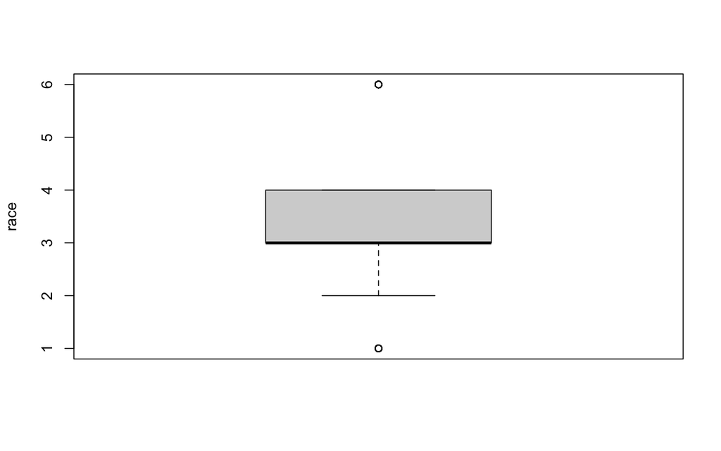

```r
boxplot(nhanes2017_prev$race, ylab = "race")
```

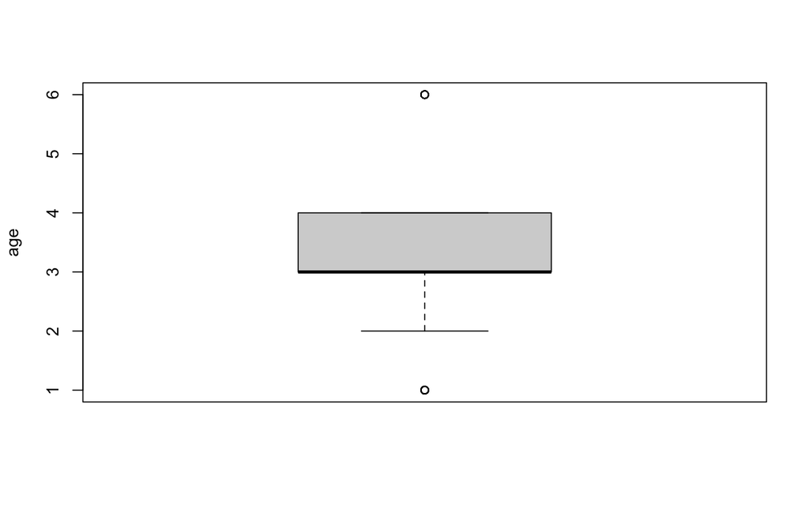

```r
boxplot(nhanes2017_prev$race, ylab = "age")
```

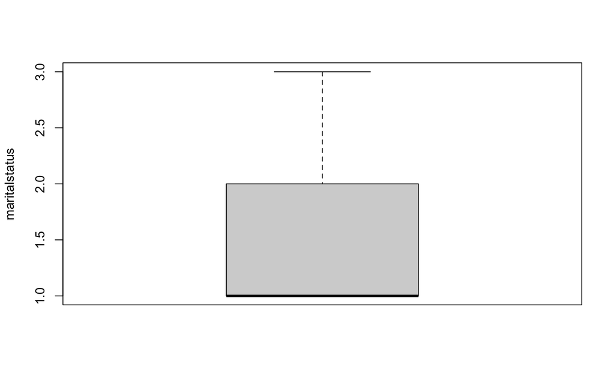

```r
boxplot(nhanes2017_prev$maritalstatus, ylab = "maritalstatus")
```

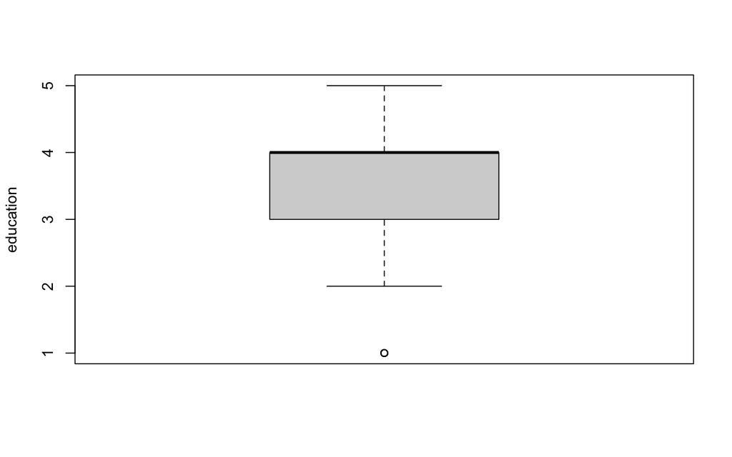

```r
boxplot(nhanes2017_prev$education, ylab = "education")
```

Combinationdoctor, medicare, medigap, medicaid, chip, statesponsored, othergovernment, havemedicare, and in ratio_poverty, a category was removed due to there being no/low numbers (too much missing data) based on category, so a new data set was created to account for this.

```r
nhanes2017_prev_sub <- nhanes2017_prev %>%
  subset(nhanes2017_prev$ratio_poverty != "Equal to the poverty level (1)", drop = TRUE) %>% #remove category from variable
  dplyr::select(everasthma, asthmaattack, gender, age, race, education,
                maritalstatus, ratio_poverty, insurancebinary, prescription_insurance,
                noinsuranceyear, erasthma, healthcondition, routinehealthcare,
                numberhealthcare, overnighthospital, mentalhealthvisit) %>%
  dplyr::filter(everasthma == "Yes") %>%
  dplyr::filter(asthmaattack == "Yes")
nhanes2017_prev_sub = data.frame(nhanes2017_prev_sub)

#Assess missingness
sapply(nhanes2017_prev_sub, function(x) sum(is.na(x)))
```

```
##             everasthma           asthmaattack                 gender
##                      0                      0                      0
##                    age                   race              education
##                      5                     15                    206
##          maritalstatus          ratio_poverty        insurancebinary
##                    206                      0                      0
## prescription_insurance        noinsuranceyear               erasthma
##                     41                     36                      0
##        healthcondition      routinehealthcare       numberhealthcare
##                      0                      0                      2
##      overnighthospital      mentalhealthvisit
##                      0                     32
```

Age, race, gender, insurance status, number of healthcare provider visits, and asthma-related ER visits distribution for asthma prevalence were plotted below.

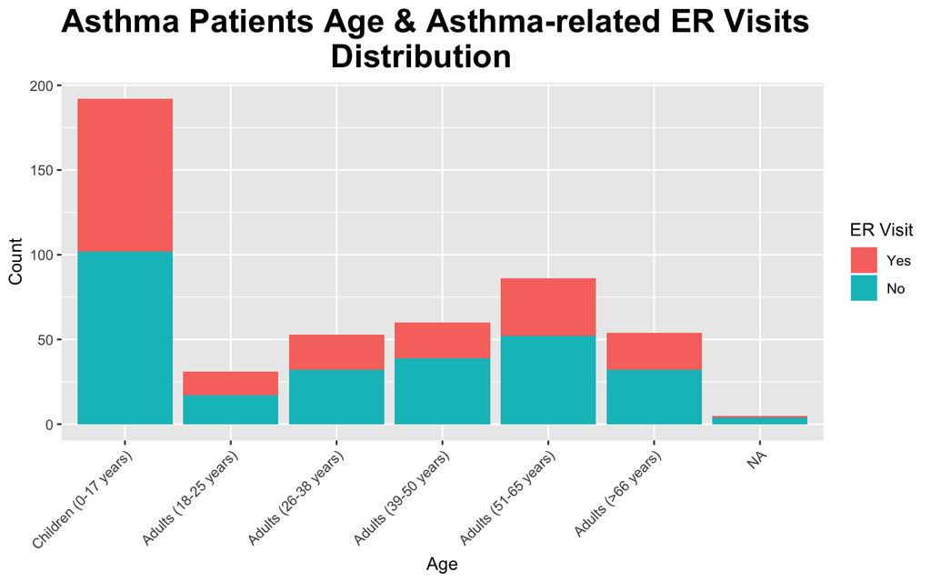

```r
p1 <- ggplot2::ggplot(data = nhanes2017_prev_sub, aes(x = age, fill = erasthma)) +
                geom_bar() +
                scale_fill_discrete(name = "ER Visit") +
                labs(title = "Asthma Patients Age & Asthma-related ER Visits
                              Distribution", x = "Age", y ="Count") +
                theme(axis.text.x = element_text(angle = 45, hjust = 1),
                plot.title = element_text(hjust = 0, face="bold", size=20))
p1
```

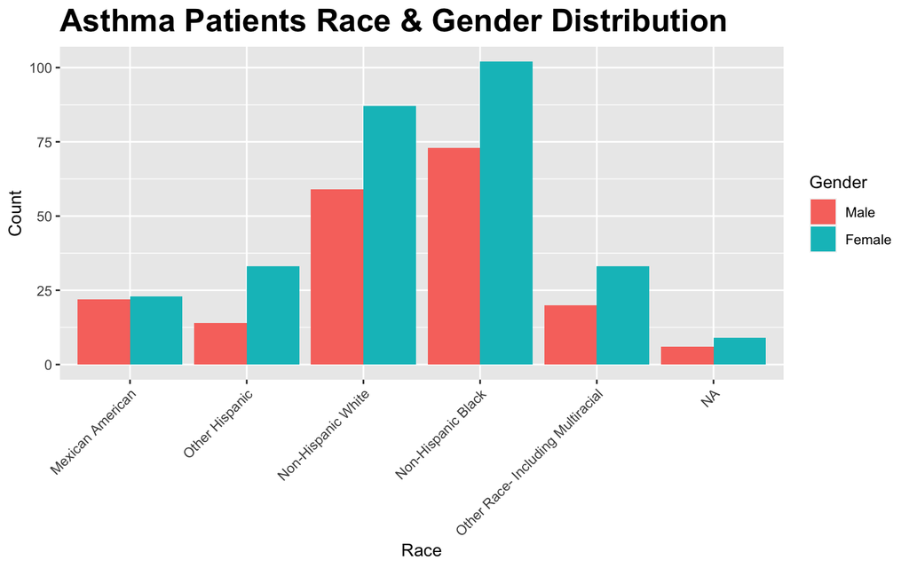

```r
p2 <- ggplot2::ggplot(data = nhanes2017_prev_sub, aes(x = race, fill = gender)) +
                geom_bar(position = "dodge") +
                scale_fill_discrete(name = "Gender") +
                labs(title = "Asthma Patients Race & Gender Distribution",
                x = "Race", y = "Count") +
                theme(axis.text.x = element_text(angle = 45, hjust = 1),
                plot.title = element_text(hjust = 0, face="bold", size=20))
p2
```

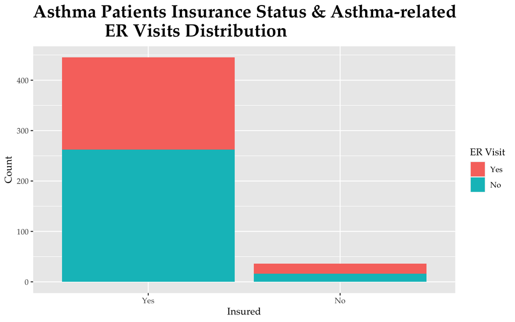

```r
p3 <- ggplot2::ggplot(data = nhanes2017_prev_sub, aes(x = insurancebinary,
                fill = erasthma)) +
                geom_bar() +
                scale_fill_discrete(name = "ER Visit") +
                labs(title = "Asthma Patients Insurance Status & Asthma-related
                ER Visits Distribution",
                x = "Insured", y = "Count") +
                theme(text = element_text(family = "Palatino"),
                plot.title = element_text(hjust = 0, face="bold", size=20))
p3
```

[figure not shown]

[output not shown]

[output not shown]

```r
p4 <- ggplot2::ggplot(data = nhanes2017_prev_sub, aes(x = numberhealthcare,
                fill = gender)) +
                geom_histogram(stat = "count") +
                labs(title = "Number of Healthcare Provider Visits in
                     Asthma Patients by Gender",
                x = "Number of Healthcare Visits in Past 12 months") +
                theme(axis.text.x = element_text(angle = 45, hjust = 1),
                plot.title = element_text(hjust = 0, face="bold", size=20))
p4
```

```r
anova(fit_glm1)
```

|  | Df | Deviance | Resid. Df | Resid. Dev |
| --- | --- | --- | --- | --- |
| NULL | NA | NA | 264 | 355.8695 |
| race | 4 | 5.7750108 | 260 | 350.0945 |
| gender | 1 | 0.1825534 | 259 | 349.9119 |
| age | 4 | 0.5173428 | 255 | 349.3946 |
| insurancebinary | 1 | 1.2735892 | 254 | 348.1210 |
| maritalstatus | 2 | 1.3217966 | 252 | 346.7992 |
| education | 4 | 10.2190371 | 248 | 336.5802 |

```r
coef(fit_glm1)
```

```
##                             (Intercept)                      raceOther Hispanic
##                             -0.01685559                             -0.80898292
##                  raceNon-Hispanic White                  raceNon-Hispanic Black
##                             -0.21634839                             -0.89052397
##   raceOther Race- Including Multiracial                            genderFemale
##                             -0.84282469                             -0.06902935
##                 ageAdults (26-38 years)                 ageAdults (39-50 years)
##                              0.24994868                              0.37930564
##                 ageAdults (51-65 years)                   ageAdults (>66 years)
##                              0.37886546                              0.38141117
##                       insurancebinaryNo maritalstatusWidowed/Divorced/Separated
##                             -0.45899136                             -0.27339486
##                     maritalstatusSingle                 education9th-11th grade
##                              0.10590947                              0.34338379
##       educationHigh school graduate/GED      educationSome college or AA degree
##                              0.69158821                              0.95216678
##      educationCollege graduate or above
##                              1.70884273
```

Regression model table created for Aim 2.

```r
Table3 <- tbl_regression(fit_glm1,
                         exponentiate = TRUE,
                         pvalue_fun = ~style_pvalue(.x, digits = 2)) %>%
                         bold_p(t = 0.10) %>%
                         bold_labels() %>%
                         italicize_levels() %>%
                         modify_caption("Table 3. Multivariate Regression Model:
                         Asthma-related ER Visits")
 Table3
```

Table 3. Multivariate Regression Model: Asthma-related ER Visits

| **Characteristic** | **OR**<sup>1</sup> | **95% CI**<sup>1</sup> | **p-value** |
| --- | --- | --- | --- |
| race |  |  |  |
| Mexican American | — | — |  |
| Other Hispanic | 0.45 | 0.11, 1.57 | 0.22 |
| Non-Hispanic White | 0.81 | 0.22, 2.57 | 0.72 |
| Non-Hispanic Black | 0.41 | 0.11, 1.31 | 0.15 |
| Other Race- Including Multiracial | 0.43 | 0.10, 1.59 | 0.22 |
| gender |  |  |  |
| Male | — | — |  |
| Female | 0.93 | 0.50, 1.71 | 0.82 |
| age |  |  |  |
| Adults (18-25 years) | — | — |  |
| Adults (18-25 years) | — | — |  |
| Adults (26-38 years) | 1.28 | 0.44, 3.71 | 0.64 |
| Adults (39-50 years) | 1.46 | 0.48, 4.40 | 0.50 |
| Adults (51-65 years) | 1.46 | 0.52, 4.09 | 0.47 |
| Adults (>66 years) | 1.46 | 0.46, 4.64 | 0.51 |
| insurancebinary |  |  |  |
| Yes | — | — |  |
| No | 0.63 | 0.25, 1.59 | 0.33 |
| maritalstatus |  |  |  |
| Married/Living with Partner | — | — |  |
| Widowed/Divorced/Separated | 0.76 | 0.40, 1.45 | 0.41 |
| Single | 1.11 | 0.56, 2.23 | 0.76 |
| education |  |  |  |
| < 9th grade | — | — |  |
| 9th-11th grade | 1.41 | 0.38, 5.45 | 0.61 |
| High school graduate/GED | 2.00 | 0.56, 7.43 | 0.29 |
| Some college or AA degree | 2.59 | 0.77, 9.14 | 0.13 |
| College graduate or above | 5.52 | 1.41, 23.2 | 0.016 |

<sup>*1*</sup> OR = Odds Ratio, CI = Confidence Interval

Forest plot created for data visualization for Aim 2 regression model.

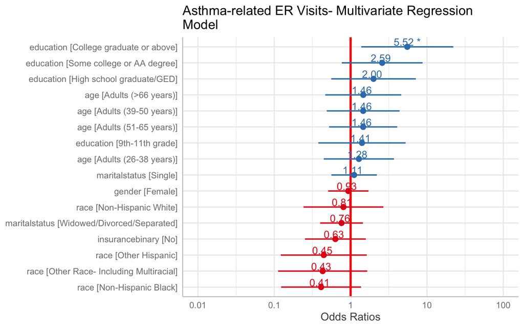

```r
theme_set(theme_sjplot())
forestplot1 <- plot_model(fit_glm1,
               vline.color = "red",
               sort.est = TRUE,
               show.values = TRUE,
               value.offset = .3,
               show.p = TRUE,
               title = "Asthma-related ER Visits- Multivariate Regression Model")
forestplot1
```

In the third aim, we looked at healthcare provider visits and emergency room visits in those with asthma (asthma prevalence group) from 2017-March 2020 in the US by using a multivariate logistic regression model.

```r
fit_glm2 <- glm(data = nhanes2017_prev, erasthma ~ numberhealthcare
                + overnighthospital + mentalhealthvisit + race + gender + age
                + maritalstatus + education + insurancebinary,
                family = binomial())

summary(fit_glm2)
```

```
##
## Call:
## glm(formula = erasthma ~ numberhealthcare + overnighthospital +
##     mentalhealthvisit + race + gender + age + maritalstatus +
##     education + insurancebinary, family = binomial(), data = nhanes2017_prev)
##
## Deviance Residuals:
##     Min       1Q   Median       3Q      Max
## -2.2964  -1.1570   0.6791   0.9224   1.8558
##
## Coefficients:
##                                         Estimate Std. Error z value Pr(>|z|)
## (Intercept)                              0.10057    0.96281   0.104  0.91681
## numberhealthcare1                       -0.70676    0.60765  -1.163  0.24479
## numberhealthcare2 to 3                  -0.54524    0.53911  -1.011  0.31184
## numberhealthcare4 to 5                  -0.51544    0.52643  -0.979  0.32752
## numberhealthcare6 to 7                  -0.64061    0.58459  -1.096  0.27315
## numberhealthcare8 to 9                  -1.03323    0.66765  -1.548  0.12173
## numberhealthcare10 to 12                -0.12984    0.60590  -0.214  0.83032
## numberhealthcare13 to 15                -0.54430    0.79776  -0.682  0.49506
## numberhealthcare16 or more              -0.40539    0.63952  -0.634  0.52614
## overnighthospitalNo                      0.50127    0.30570   1.640  0.10105
## mentalhealthvisitNo                      0.81566    0.27924   2.921  0.00349 **
## raceOther Hispanic                      -0.60097    0.55228  -1.088  0.27652
## raceNon-Hispanic White                  -0.21356    0.49904  -0.428  0.66870
## raceNon-Hispanic Black                  -0.91923    0.51241  -1.794  0.07282 .
## raceOther Race- Including Multiracial   -0.64447    0.57623  -1.118  0.26339
## genderFemale                             0.03700    0.26746   0.138  0.88996
## ageAdults (26-38 years)                  0.05023    0.50021   0.100  0.92001
## ageAdults (39-50 years)                  0.08027    0.50655   0.158  0.87409
## ageAdults (51-65 years)                  0.27277    0.48052   0.568  0.57027
## ageAdults (>66 years)                    0.17661    0.55581   0.318  0.75068
## maritalstatusWidowed/Divorced/Separated -0.31315    0.29711  -1.054  0.29190
## maritalstatusSingle                     -0.14827    0.32190  -0.461  0.64509
## education9th-11th grade                 -0.11888    0.62272  -0.191  0.84860
## educationHigh school graduate/GED        0.40072    0.59373   0.675  0.49973
## educationSome college or AA degree       0.45224    0.56369   0.802  0.42238
## educationCollege graduate or above       1.27471    0.62561   2.038  0.04160 *
## insurancebinaryNo                       -0.55317    0.44333  -1.248  0.21212
## ---
## Signif. codes:  0 '***' 0.001 '**' 0.01 '*' 0.05 '.' 0.1 ' ' 1
##
## (Dispersion parameter for binomial family taken to be 1)
##
##     Null deviance: 467.31  on 355  degrees of freedom
## Residual deviance: 425.47  on 329  degrees of freedom
##   (280 observations deleted due to missingness)
## AIC: 479.47
##
## Number of Fisher Scoring iterations: 4
```

```r
anova(fit_glm2)
```

|  | Df | Deviance | Resid. Df | Resid. Dev |
| --- | --- | --- | --- | --- |
| NULL | NA | NA | 355 | 467.3099 |
| numberhealthcare | 8 | 3.3741594 | 347 | 463.9357 |
| overnighthospital | 1 | 6.5753619 | 346 | 457.3604 |
| mentalhealthvisit | 1 | 9.1980233 | 345 | 448.1624 |
| race | 4 | 7.6114857 | 341 | 440.5509 |
| gender | 1 | 0.3342608 | 340 | 440.2166 |
| age | 4 | 0.4773313 | 336 | 439.7393 |
| maritalstatus | 2 | 1.2644940 | 334 | 438.4748 |
| education | 4 | 11.4603778 | 330 | 427.0144 |
| insurancebinary | 1 | 1.5396832 | 329 | 425.4747 |

```r
coef(fit_glm2)
```

```
##                             (Intercept)                       numberhealthcare1
##                              0.10056819                             -0.70675744
##                  numberhealthcare2 to 3                  numberhealthcare4 to 5
##                             -0.54523927                             -0.51543783
##                  numberhealthcare6 to 7                  numberhealthcare8 to 9
##                             -0.64061472                             -1.03322592
##                numberhealthcare10 to 12                numberhealthcare13 to 15
##                             -0.12984081                             -0.54429934
##              numberhealthcare16 or more                     overnighthospitalNo
##                             -0.40539458                              0.50127407
##                     mentalhealthvisitNo                      raceOther Hispanic
##                              0.81565987                             -0.60097315
##                  raceNon-Hispanic White                  raceNon-Hispanic Black
##                             -0.21356047                             -0.91923182
##   raceOther Race- Including Multiracial                            genderFemale
##                             -0.64446956                              0.03700317
##                 ageAdults (26-38 years)                 ageAdults (39-50 years)
##                              0.05023225                              0.08026723
##                 ageAdults (51-65 years)                   ageAdults (>66 years)
##                              0.27276526                              0.17660615
## maritalstatusWidowed/Divorced/Separated                     maritalstatusSingle
##                             -0.31314933                             -0.14826532
##                 education9th-11th grade       educationHigh school graduate/GED
##                             -0.11888074                              0.40071797
##      educationSome college or AA degree      educationCollege graduate or above
##                              0.45224361                              1.27470605
##                       insurancebinaryNo
##                             -0.55316904
```

Regression model table created for Aim 3.

```r
Table4 <- tbl_regression(fit_glm2,
                         exponentiate = TRUE,
                         pvalue_fun = ~style_pvalue(.x, digits = 2)) %>%
                         bold_p(t = 0.10) %>%
                         bold_labels() %>%
                         italicize_levels() %>%
                         modify_caption("Table 4. Multivariate Regression Model:
                         Healthcare Provider Visits and Asthma-related
                         ER Visits")
Table4
```

Table 4. Multivariate Regression Model: Healthcare Provider Visits and Asthma-related ER Visits

| **Characteristic** | **OR**<sup>1</sup> | **95% CI**<sup>1</sup> | **p-value** |
| --- | --- | --- | --- |
| numberhealthcare |  |  |  |
| None | — | — |  |
| 1 | 0.49 | 0.15, 1.61 | 0.24 |
| 2 to 3 | 0.58 | 0.19, 1.62 | 0.31 |
| 4 to 5 | 0.60 | 0.20, 1.63 | 0.33 |
| 6 to 7 | 0.53 | 0.16, 1.62 | 0.27 |
| 8 to 9 | 0.36 | 0.09, 1.30 | 0.12 |
| 10 to 12 | 0.88 | 0.26, 2.86 | 0.83 |
| 13 to 15 | 0.58 | 0.12, 2.86 | 0.50 |
| 16 or more | 0.67 | 0.19, 2.33 | 0.53 |
| overnighthospital |  |  |  |
| Yes | — | — |  |
| No | 1.65 | 0.91, 3.01 | 0.10 |
| mentalhealthvisit |  |  |  |
| Yes | — | — |  |
| No | 2.26 | 1.31, 3.92 | 0.003 |
| race |  |  |  |
| Mexican American | — | — |  |
| Other Hispanic | 0.55 | 0.18, 1.59 | 0.28 |
| Non-Hispanic White | 0.81 | 0.29, 2.08 | 0.67 |
| Non-Hispanic Black | 0.40 | 0.14, 1.06 | 0.073 |
| Other Race- Including Multiracial | 0.52 | 0.16, 1.59 | 0.26 |
| gender |  |  |  |
| Male | — | — |  |
| Female | 1.04 | 0.61, 1.75 | 0.89 |
| age |  |  |  |
| Adults (18-25 years) | — | — |  |
| Adults (18-25 years) | — | — |  |
| Adults (26-38 years) | 1.05 | 0.39, 2.79 | 0.92 |
| Adults (39-50 years) | 1.08 | 0.40, 2.91 | 0.87 |
| Adults (51-65 years) | 1.31 | 0.50, 3.35 | 0.57 |
| Adults (>66 years) | 1.19 | 0.40, 3.55 | 0.75 |
| maritalstatus |  |  |  |
| Married/Living with Partner | — | — |  |
| Widowed/Divorced/Separated | 0.73 | 0.41, 1.31 | 0.29 |
| Single | 0.86 | 0.46, 1.63 | 0.65 |
| education |  |  |  |
| < 9th grade | — | — |  |
| 9th-11th grade | 0.89 | 0.26, 3.03 | 0.85 |
| High school graduate/GED | 1.49 | 0.46, 4.83 | 0.50 |
| Some college or AA degree | 1.57 | 0.52, 4.80 | 0.42 |
| College graduate or above | 3.58 | 1.05, 12.4 | 0.042 |
| insurancebinary |  |  |  |
| Yes | — | — |  |
| No | 0.58 | 0.24, 1.38 | 0.21 |

<sup>*1*</sup> OR = Odds Ratio, CI = Confidence Interval

Forest plot created for data visualization for Aim 3.

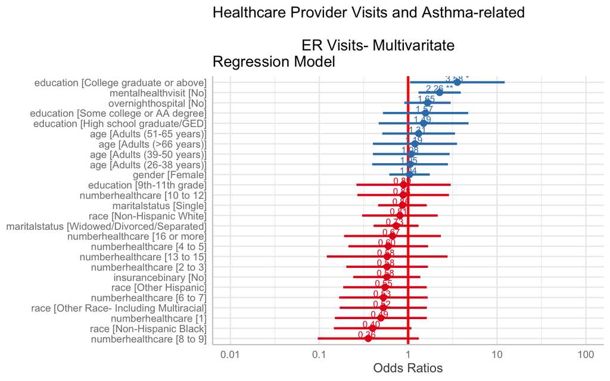

```r
theme_set(theme_sjplot())
forestplot2 <- plot_model(fit_glm2,
                          vline.color = "red",
                          sort.est = TRUE,
                          show.values = TRUE,
                          value.offset = .4,
                          value.size = 3,
                          line.size = 1,
                          title = "Healthcare Provider Visits and Asthma-related
                          ER Visits- Multivaritate Regression Model")
forestplot2
```

### Conclusions

The point prevalence of asthma in the total cohort population from 2017-March 2020 is 4.1%. Asthma-related emergency room visits (in 12 months) is significantly associated with being a college graduate or above (OR = 5.52, p-value = 0.016, 95% CI 1.41-23.2). Healthcare provider visits and asthma-related emergency room visits (in 12 months) is significantly associated with being a college graduate or above (OR = 3.58, p-value = 0.042, 95% CI 1.05-12.4) and not going to a mental health visit in 12 months (OR = 2.26, p-value = 0.003, 95% CI 1.31-3.92). There was no significant association with being Non-Hispanic Black (OR = 0.40, p-value = 0.073, 95% CI 0.14-1.06). There is no significant association between the number of healthcare provider visits in 12 months and asthma-related emergency room visits.

Several relevant variables were excluded in this report, as one limitation is the number of missing data, and lack of comparable groups within variables such ratio to poverty. Additionally, since the data was collected in a cross-sectional design, comparisons of variables across time for the same participant was not possible. Future studies should include longitudinal data, to properly compare risk factors given time. This report also did not account for other health conditions and/or lifestyle choices that can be contributory to asthma-related flares such as COPD and cigarette smoking, so future studies should examine this. Lastly, this report was not weighted, so further analysis should be done to make it generalizable to the US population.

### References

1. Centers for Disease Control and Prevention. (2018, May 18). Asthma - table -1 - lifetime asthma prevalence percents by age, NHIS, 2016. Centers for Disease Control and Prevention. Retrieved November 2, 2021, from https://www.cdc.gov/asthma/nhis/2016/table2-1.htm.
2. Nunes, C., Pereira, A. M., & Morais-Almeida, M. (2017). Asthma costs and Social Impact. Asthma Research and Practice, 3(1). https://doi.org/10.1186/s40733-016-0029-3